# Chopsticks!

A few researchers set out to determine the optimal length of chopsticks for children and adults. They came up with a measure of how effective a pair of chopsticks performed, called the "Food Pinching Performance." The "Food Pinching Performance" was determined by counting the number of peanuts picked and placed in a cup (PPPC).

### An investigation for determining the optimum length of chopsticks.

[Link to Abstract and Paper](http://www.ncbi.nlm.nih.gov/pubmed/15676839)  
*the abstract below was adapted from the link*

Chopsticks are one of the most simple and popular hand tools ever invented by humans, but have not previously been investigated by ergonomists. Two laboratory studies were conducted in this research, using a [randomised complete block design](http://dawg.utk.edu/glossary/whatis_rcbd.htm), to evaluate the effects of the length of the chopsticks on the food-serving performance of adults and children. Thirty-one male junior college students and 21 primary school pupils served as subjects for the experiment to test chopsticks lengths of 180, 210, 240, 270, 300, and 330 mm. The results showed that the food-pinching performance was significantly affected by the length of the chopsticks, and that chopsticks of about 240 and 180 mm long were optimal for adults and pupils, respectively. Based on these findings, the researchers suggested that families with children should provide both 240 and 180 mm long chopsticks. In addition, restaurants could provide 210 mm long chopsticks, considering the trade-offs between ergonomics and cost.

### For the rest of this project, answer all questions based only on the part of the experiment analyzing the thirty-one adult male college students.

Download the [data set for the adults](https://www.udacity.com/api/nodes/4576183932/supplemental_media/chopstick-effectivenesscsv/download), then answer the following questions based on the abstract and the data set.

**If you double click on this cell**, you will see the text change so that all of the formatting is removed. This allows you to edit this block of text. This block of text is written using [Markdown](http://daringfireball.net/projects/markdown/syntax), which is a way to format text using headers, links, italics, and many other options. You will learn more about Markdown later in the Nanodegree Program. Hit shift + enter or shift + return to show the formatted text.

#### 1. What is the independent variable in the experiment?

The length of the chopsticks in millimeters.

#### 2. What is the dependent variable in the experiment?

The food serving performance.

#### 3. How is the dependent variable operationally defined?

The number of peanuts picked and placed in a cup (PPPC).

#### 4. Based on the description of the experiment and the data set, list at least two variables that you know were controlled.

##### Age and Sex

Although the wording does not indicate that the primary school students were controlled for sex, the college juniors were. The fact that there were no infants, elderly, or even mature adults suggests that the experimenters were controlling for age and the other lurking variables that may accompany it (eg. years of experience which may vary more widely over a population of older people).

One great advantage of ipython notebooks is that you can document your data analysis using code, add comments to the code, or even add blocks of text using Markdown. These notebooks allow you to collaborate with others and share your work. For now, let's see some code for doing statistics.

```python
import pandas as pd

# pandas is a software library for data manipulation and analysis
# We commonly use shorter nicknames for certain packages. Pandas is often abbreviated to pd.
# hit shift + enter to run this cell or block of code
```

```python
path = r'~/Desktop/Udacity/DataScience/P0-ChopSticks/chopstick-effectiveness.csv'
# Change the path to the location where the chopstick-effectiveness.csv file is located on your computer.
# If you get an error when running this block of code, be sure the chopstick-effectiveness.csv is located at the path on your computer.

dataFrame = pd.read_csv(path)
dataFrame
```

|  | Food.Pinching.Efficiency | Individual | Chopstick.Length |
| --- | --- | --- | --- |
| 0 | 19.55 | 1 | 180 |
| 1 | 27.24 | 2 | 180 |
| 2 | 28.76 | 3 | 180 |
| 3 | 31.19 | 4 | 180 |
| 4 | 21.91 | 5 | 180 |
| 5 | 27.62 | 6 | 180 |
| 6 | 29.46 | 7 | 180 |
| 7 | 26.35 | 8 | 180 |
| 8 | 26.69 | 9 | 180 |
| 9 | 30.22 | 10 | 180 |
| 10 | 27.81 | 11 | 180 |
| 11 | 23.46 | 12 | 180 |
| 12 | 23.64 | 13 | 180 |
| 13 | 27.85 | 14 | 180 |
| 14 | 20.62 | 15 | 180 |
| 15 | 25.35 | 16 | 180 |
| 16 | 28.00 | 17 | 180 |
| 17 | 23.49 | 18 | 180 |
| 18 | 27.77 | 19 | 180 |
| 19 | 18.48 | 20 | 180 |
| 20 | 23.01 | 21 | 180 |
| 21 | 22.66 | 22 | 180 |
| 22 | 23.24 | 23 | 180 |
| 23 | 22.82 | 24 | 180 |
| 24 | 17.94 | 25 | 180 |
| 25 | 26.67 | 26 | 180 |
| 26 | 28.98 | 27 | 180 |
| 27 | 21.48 | 28 | 180 |
| 28 | 14.47 | 29 | 180 |
| 29 | 28.29 | 30 | 180 |
| ... | ... | ... | ... |
| 156 | 26.18 | 2 | 330 |
| 157 | 25.93 | 3 | 330 |
| 158 | 28.61 | 4 | 330 |
| 159 | 20.54 | 5 | 330 |
| 160 | 26.44 | 6 | 330 |
| 161 | 29.36 | 7 | 330 |
| 162 | 19.77 | 8 | 330 |
| 163 | 31.69 | 9 | 330 |
| 164 | 24.64 | 10 | 330 |
| 165 | 22.09 | 11 | 330 |
| 166 | 23.42 | 12 | 330 |
| 167 | 28.63 | 13 | 330 |
| 168 | 26.30 | 14 | 330 |
| 169 | 22.89 | 15 | 330 |
| 170 | 22.68 | 16 | 330 |
| 171 | 30.92 | 17 | 330 |
| 172 | 20.74 | 18 | 330 |
| 173 | 27.24 | 19 | 330 |
| 174 | 17.12 | 20 | 330 |
| 175 | 23.63 | 21 | 330 |
| 176 | 20.91 | 22 | 330 |
| 177 | 23.49 | 23 | 330 |
| 178 | 24.86 | 24 | 330 |
| 179 | 16.28 | 25 | 330 |
| 180 | 21.52 | 26 | 330 |
| 181 | 27.22 | 27 | 330 |
| 182 | 17.41 | 28 | 330 |
| 183 | 16.42 | 29 | 330 |
| 184 | 28.22 | 30 | 330 |
| 185 | 27.52 | 31 | 330 |

186 rows × 3 columns

Let's do a basic statistical calculation on the data using code! Run the block of code below to calculate the average "Food Pinching Efficiency" for all 31 participants and all chopstick lengths.

```python
dataFrame['Food.Pinching.Efficiency'].mean()
```

```
25.00559139784947
```

This number is helpful, but the number doesn't let us know which of the chopstick lengths performed best for the thirty-one male junior college students. Let's break down the data by chopstick length. The next block of code will generate the average "Food Pinching Effeciency" for each chopstick length. Run the block of code below.

```python
meansByChopstickLength = dataFrame.groupby('Chopstick.Length')['Food.Pinching.Efficiency'].mean().reset_index()
meansByChopstickLength

# reset_index() changes Chopstick.Length from an index to column. Instead of the index being the length of the chopsticks, the index is the row numbers 0, 1, 2, 3, 4, 5.
```

|  | Chopstick.Length | Food.Pinching.Efficiency |
| --- | --- | --- |
| 0 | 180 | 24.935161 |
| 1 | 210 | 25.483871 |
| 2 | 240 | 26.322903 |
| 3 | 270 | 24.323871 |
| 4 | 300 | 24.968065 |
| 5 | 330 | 23.999677 |

#### 5. Which chopstick length performed the best for the group of thirty-one male junior college students?

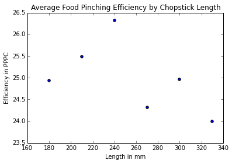

```python
# Causes plots to display within the notebook rather than in a new window
%pylab inline

import matplotlib.pyplot as plt

plt.scatter(x=meansByChopstickLength['Chopstick.Length'], y=meansByChopstickLength['Food.Pinching.Efficiency'])
            # title="")
plt.xlabel("Length in mm")
plt.ylabel("Efficiency in PPPC")
plt.title("Average Food Pinching Efficiency by Chopstick Length")
plt.show()
```

#### 6. Based on the scatterplot created from the code above, interpret the relationship you see. What do you notice?

Proficiency seems to increase with chopstick length untill the 240mm point is reached. There is a steep decline in performance from the 240mm chopsticks and the 270mm chopsticks followed by another increase that does not continue to form a trend in the way that the first three data points seem to.

### In the abstract the researchers stated that their results showed food-pinching performance was significantly affected by the length of the chopsticks, and that chopsticks of about 240 mm long were optimal for adults.

#### 7a. Based on the data you have analyzed, do you agree with the claim?

It is an appealing claim, but I do not agree.

#### 7b. Why?

The variability of the average PPPC efficiencies of the subjects across the different chopstick sizes is too small to make the 240mm difference significant.

#### Overview

What follows is a brief outline of how I arrived at this conclusion as well as some other thoughts that I've had on the data.

1. **A Quick Visualization:** Although scatter plots are nice, they can be misleading. I believe the one included above is one such example.
2. **Variability:** We are not presented with an analysis of the variability in the data. I would like to see the standard deviation of the measured efficiencies before claiming significane.
3. **Lurking Variables:** It maybe worth investigating the the performances of the individual subjects in order to discern any anomalies that may be influencing our results, especially given the small sample size.

### Note: *This is still a rough draft, but since it's the first project, I'll submit it like this to see if I'm on the right track.*

### 1. Scale - a quick visualization

We were told in class to be mindful of misleading charts and the scatter plot of means seems suspicious to me. Just as a sanity check, let's see the difference in performance under a different light.

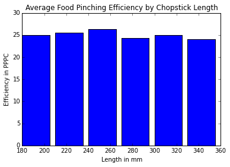

```python
plt.bar(left=meansByChopstickLength['Chopstick.Length'],
        height=meansByChopstickLength['Food.Pinching.Efficiency'],
        bottom=0,
        width=25
       )
plt.xlabel("Length in mm")
plt.ylabel("Efficiency in PPPC")
plt.title("Average Food Pinching Efficiency by Chopstick Length")
plt.show()
```

These differences don't look quite so stark as they did in the scatter plot. In fact, to look at them this way these results look as though they may come from a uniform distribution. This seems like a reasonable motivation to investigate further.

### As discussed in class, the mean may not always be the most appropriate measure of center to apply. So let's at least look at the median also.

```python
dataFrame['Food.Pinching.Efficiency'].median()
```

```
24.905
```

```python
mediansByChopstickLength = dataFrame.groupby('Chopstick.Length')['Food.Pinching.Efficiency'].median().reset_index()
mediansByChopstickLength
```

|  | Chopstick.Length | Food.Pinching.Efficiency |
| --- | --- | --- |
| 0 | 180 | 26.35 |
| 1 | 210 | 25.42 |
| 2 | 240 | 26.43 |
| 3 | 270 | 24.50 |
| 4 | 300 | 25.09 |
| 5 | 330 | 23.63 |

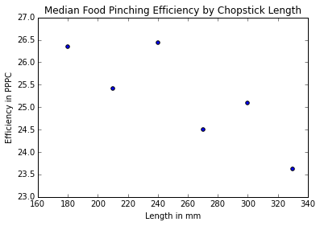

```python
plt.scatter(x=mediansByChopstickLength['Chopstick.Length'], y=mediansByChopstickLength['Food.Pinching.Efficiency'])
            # title="")
plt.xlabel("Length in mm")
plt.ylabel("Efficiency in PPPC")
plt.title("Median Food Pinching Efficiency by Chopstick Length")
plt.show()
```

### Hmmm, this seems to be telling a slightly different story than the mean average.

While it still looks reasonably safe to say that 240mm is a good candidate to be the optimal chopstick length, this plot seems indicate that performance decreases with chopstick length. Certainly, using the median as our method of center the favorability of the 180mm chopstick has changed. But as we've already noted, this may not be the most appropriate way to view the data. Let's try the bar plot again.

[figure not shown]

```python
plt.bar(left=mediansByChopstickLength['Chopstick.Length'],
        height=mediansByChopstickLength['Food.Pinching.Efficiency'],
        bottom=0,
        width=25
       )
plt.xlabel("Length in mm")
plt.ylabel("Efficiency in PPPC")
plt.title("Average Food Pinching Efficiency by Chopstick Length")
plt.show()
```

Once again, this does not look like a case for a significant advantage for the 240mm group.

### 2. Variability

In order to establish significance we need to have a sense of variablility. Let's take a look at the standard deviation between the PPPC efficiencies of the subjects across the different chopstick lengths.

```python
dataFrame['Food.Pinching.Efficiency'].std()
```

```
4.03969291376798
```

and also within each chopstick length experiment.

```python
standardDeviationsByChopstickLength = dataFrame.groupby('Chopstick.Length')['Food.Pinching.Efficiency'].std().reset_index()
standardDeviationsByChopstickLength
```

|  | Chopstick.Length | Food.Pinching.Efficiency |
| --- | --- | --- |
| 0 | 180 | 4.020612 |
| 1 | 210 | 4.116344 |
| 2 | 240 | 4.457579 |
| 3 | 270 | 3.713268 |
| 4 | 300 | 3.560044 |
| 5 | 330 | 4.198898 |

Let's put these numbers in some context. The range of the means for each group was:

```python
means = meansByChopstickLength['Food.Pinching.Efficiency']
range_of_means = max(means) - min(means)
range_of_means
```

```
2.3232258064516209
```

Which seems quite a lot smaller than the standard deviation of the sample.

*At this point I'm having some trouble articulating exactly why this is so telling. My instinct is that we can hypothosize about the distribution of chopstick length efficiencies being normal and find the probability of randomly selected length differing from the mean by the scale that the 240mm example does. I feel like that it would approach a near certainty that it would. In other words, not only is there not evidence that 240mm is the optimal length for chopsticks, running the same experiment over again might as easily place the resulting mean of efficiencies as far from the average in the opposite direction. But again, this is a draft and I plan to continue working away at this problem.*

### Histogram

While it is nice to have the averages displayed on a scatter chart, I thought that there might be more insight to be drawn from looking at the histogram representations of the subject's efficiencies with each length of chopstick.

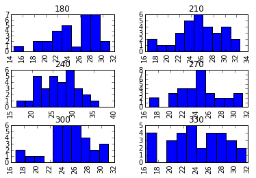

```python
histograms = pd.DataFrame.hist(dataFrame, column='Food.Pinching.Efficiency', by='Chopstick.Length')
```

It looks as though the results from the 180mm chopstick experiment skew negatively.

*I'm still working out what this means also. I find myself having to resist the urge to find significance in the data to support my own hunches.*

## 4. Potential Lurking Variables

#### We don't know the distribution of chopstick skills in the population, but with such a small sample could it be the case that a few sucjects with a lot of practice are skewing the results?

Let's look at the individual efficiencies.

### Let's analayze variablity of the performance of individual subjects across chopstick lengths and change the layout to be a little bit more intuitive.

```python
indiviual_efficiency_by_chopstick_length = dataFrame.pivot(index='Individual', columns='Chopstick.Length')
ops = ['median', 'mean', 'var', 'std']
chopstick_data = indiviual_efficiency_by_chopstick_length.copy()
for op in ops:
    chopstick_data[op] = eval('indiviual_efficiency_by_chopstick_length.T.'+op+'()')
chopstick_data
```

| Chopstick.Length Individual | Food.Pinching.Efficiency 180 | Food.Pinching.Efficiency 210 | Food.Pinching.Efficiency 240 | Food.Pinching.Efficiency 270 | Food.Pinching.Efficiency 300 | Food.Pinching.Efficiency 330 | median | mean | var | std |
| --- | --- | --- | --- | --- | --- | --- | --- | --- | --- | --- |
| 1 | 19.55 | 23.53 | 21.34 | 24.40 | 22.50 | 21.32 | 21.920 | 22.106667 | 3.036627 | 1.742592 |
| 2 | 27.24 | 26.39 | 29.94 | 25.88 | 23.10 | 26.18 | 26.285 | 26.455000 | 4.885590 | 2.210337 |
| 3 | 28.76 | 30.90 | 32.95 | 27.97 | 28.26 | 25.93 | 28.510 | 29.128333 | 6.040937 | 2.457832 |
| 4 | 31.19 | 26.05 | 29.40 | 24.54 | 25.55 | 28.61 | 27.330 | 27.556667 | 6.621107 | 2.573151 |
| 5 | 21.91 | 23.27 | 22.32 | 22.66 | 16.71 | 20.54 | 22.115 | 21.235000 | 5.752670 | 2.398472 |
| 6 | 27.62 | 29.17 | 28.36 | 28.94 | 27.88 | 26.44 | 28.120 | 28.068333 | 0.989297 | 0.994634 |
| 7 | 29.46 | 30.93 | 28.49 | 30.72 | 31.07 | 29.36 | 30.090 | 30.005000 | 1.101870 | 1.049700 |
| 8 | 26.35 | 17.55 | 22.24 | 16.70 | 23.44 | 19.77 | 21.005 | 21.008333 | 13.603737 | 3.688324 |
| 9 | 26.69 | 32.55 | 36.15 | 30.27 | 28.82 | 31.69 | 30.980 | 31.028333 | 10.651537 | 3.263669 |
| 10 | 30.22 | 28.87 | 30.62 | 26.29 | 27.77 | 24.64 | 28.320 | 28.068333 | 5.357657 | 2.314661 |
| 11 | 27.81 | 26.53 | 26.53 | 22.33 | 24.54 | 22.09 | 25.535 | 24.971667 | 5.676337 | 2.382506 |
| 12 | 23.46 | 25.26 | 27.95 | 24.85 | 24.55 | 23.42 | 24.700 | 24.915000 | 2.763950 | 1.662513 |
| 13 | 23.64 | 25.65 | 31.49 | 24.33 | 27.78 | 28.63 | 26.715 | 26.920000 | 8.725600 | 2.953913 |
| 14 | 27.85 | 29.39 | 30.24 | 24.50 | 26.14 | 26.30 | 27.075 | 27.403333 | 4.687147 | 2.164982 |
| 15 | 20.62 | 23.26 | 24.80 | 22.67 | 23.44 | 22.89 | 23.075 | 22.946667 | 1.853907 | 1.361582 |
| 16 | 25.35 | 24.77 | 26.43 | 22.28 | 26.44 | 22.68 | 25.060 | 24.658333 | 3.274857 | 1.809657 |
| 17 | 28.00 | 25.42 | 29.35 | 23.80 | 27.47 | 30.92 | 27.735 | 27.493333 | 6.677187 | 2.584025 |
| 18 | 23.49 | 23.65 | 21.15 | 25.36 | 24.94 | 20.74 | 23.570 | 23.221667 | 3.646217 | 1.909507 |
| 19 | 27.77 | 32.22 | 29.18 | 29.50 | 29.68 | 27.24 | 29.340 | 29.265000 | 3.060470 | 1.749420 |
| 20 | 18.48 | 18.86 | 21.60 | 20.19 | 24.33 | 17.12 | 19.525 | 20.096667 | 6.638667 | 2.576561 |
| 21 | 23.01 | 21.75 | 25.39 | 20.14 | 25.42 | 23.63 | 23.320 | 23.223333 | 4.281667 | 2.069219 |
| 22 | 22.66 | 23.07 | 22.26 | 21.09 | 24.64 | 20.91 | 22.460 | 22.438333 | 1.896217 | 1.377032 |
| 23 | 23.24 | 22.30 | 24.85 | 24.78 | 22.78 | 23.49 | 23.365 | 23.573333 | 1.090947 | 1.044484 |
| 24 | 22.82 | 27.04 | 24.56 | 24.74 | 26.50 | 24.86 | 24.800 | 25.086667 | 2.279947 | 1.509949 |
| 25 | 17.94 | 22.24 | 16.35 | 22.73 | 18.71 | 16.28 | 18.325 | 19.041667 | 8.005737 | 2.829441 |
| 26 | 26.67 | 24.87 | 22.96 | 21.08 | 22.86 | 21.52 | 22.910 | 23.326667 | 4.444707 | 2.108247 |
| 27 | 28.98 | 30.85 | 25.82 | 25.70 | 25.09 | 27.22 | 26.520 | 27.276667 | 5.012507 | 2.238863 |
| 28 | 21.48 | 21.15 | 19.46 | 19.79 | 19.72 | 17.41 | 19.755 | 19.835000 | 2.094350 | 1.447187 |
| 29 | 14.47 | 16.47 | 23.60 | 16.82 | 17.05 | 16.42 | 16.645 | 17.471667 | 9.855657 | 3.139372 |
| 30 | 28.29 | 29.05 | 33.10 | 31.15 | 30.91 | 28.22 | 29.980 | 30.120000 | 3.733840 | 1.932315 |
| 31 | 27.97 | 26.99 | 27.13 | 27.84 | 25.92 | 27.52 | 27.325 | 27.228333 | 0.557497 | 0.746657 |

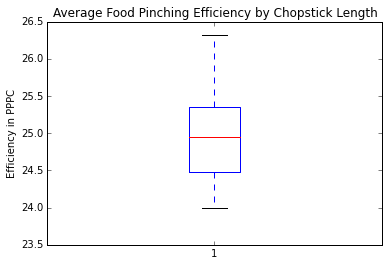

```python
plt.boxplot(x=meansByChopstickLength['Food.Pinching.Efficiency'])

plt.ylabel("Efficiency in PPPC")
plt.title("Average Food Pinching Efficiency by Chopstick Length")
plt.show()
```